# Introduction to Zotero

## 1 文献管理工具

文献管理很多，以下只是罗列几个。本人使用 Zotero, 下文仅仅介绍 Zotero

- [zotero](https://www.zotero.org)
- [mendeley](https://www.mendeley.com)
- [jabref](https://www.jabref.org/)
- [noteExpress](http://zj11.yingxunsz.cn/NoteExp21ress/): 中文环境，商业软件
- [endnote](https://endnote.com/): 英文环境，商业软件

## 2 Zotero 下载安装

- zotero standalone (单机版)
- zotero connector: chrome, firefox, safari, edge

有关 Zotero Connector 的 Chrome 插件，多说几句。Zotero 官网默认从 google 商店下载安装 Zotero 的 Chrome 插件，国内用户使用 google 商店存在障碍。 替代方案 1：使用其它浏览器，如火狐或微软的 Edge；替代方案 2：手动安装 Chrome 插件

在 chrome 安装 Zotero Connector 插件，主要有以下步骤：

步骤1：搜索并下载 Zotero Connector 的 `crx` 文件, 将文件扩展名从 “.crx” 改为 “.rar”, 然后解压缩

步骤2：如 图 1 所示，打开 Chrome 的扩展程序管理界面

[figure not shown]

图 1: 打开 Chrome 扩展

步骤3：按照 图 2 顺序手动安装 Zotero 插件

[figure not shown]

图 2: Chrome 手动安装插件

选择上述解压文件所在的文件夹 (如 e:/sftwr/zotero_chrome_connector_plugin), 按确定即完成插件的安装

## 3 Zotero 插件的安装

为方便 Zotero 的使用，我们可以安装配套的插件。常用的插件有: ZotFile, Zotero Style Editor 等。如 ZotFile 插件可以实现自动修改附件名、提取附件中的笔记等功能。 可以从 https://www.zotero.org/support/plugins 浏览这些插件

插件安装步骤如下：

- 步骤1：下载插件文件
- 步骤2：工具 –> 插件, 点击右上角齿轮状按钮，选择 Install Add-on From File，选中需要安装的插件。安装完毕后重启 Zotero 即可

## 4 同步的配置

包括数据同步 (data syncing) 和文件同步 (file syncing)。前者同步除了附件以外的诸如文献条目、条目等信息，后者同步附件（如 pdf 文档）。

数据同步完全免费，并且没有储存空间的限制。文件同步 Zotero 官网仅仅提供 300M 的免费空间，扩容需要购买。替代方案是使用 WebDAV，我们随后后专门介绍。

数据同步主要的步骤：

- 步骤1：在 Zotero 官网注册账号
- 步骤2：在 Zotero 里点击: 编辑 (edit) –> 首选项 (preferences) –> 同步 (sync)，输入账号、密码即可

使用 WebDAV (web-based distributed authoring and versioning) 进行文件同步较为复杂。WebDAV 是一种基于 HTTP 1.1 协议的通信协议，推荐使用坚果云

步骤1：登录坚果云账号，点击右上角 “用户名” –> “账户信息” –> “安全选项” –> “第三方应用管理”, 点击 “添加应用”，输入应用名 “zotero”，记住 “服务器地址”、“账户” 和 “密码” 等信息；

步骤2：在 Zotero 界面，点击 “首选项” –> “同步”, 按照 图 3 所示 设置同步文件

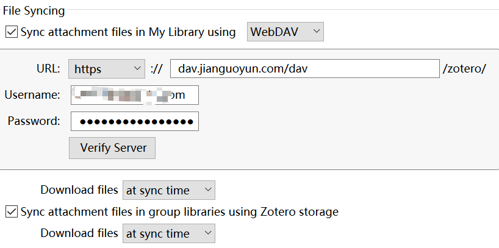

图 3: zotero 与坚果云同步

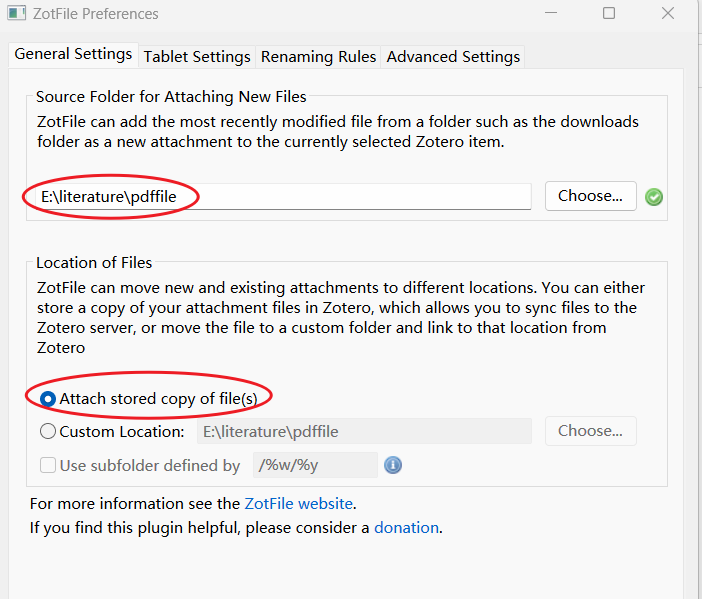

Zotero 的配置

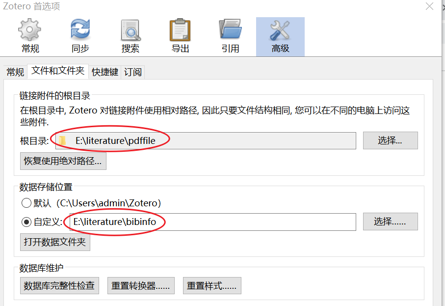

图 4: Zotero 中路径的设置

## 5 文献的引用

包括引用样式的添加和在字处理软件中引用 Zotero 文献数据库

### 5.1 引用样式添加

添加引用样式 (cytation style language, csl)，点击“首选项” –> “引用” –> “获取更多样式” (get additional styles), 搜索需要的样式，如 7714， 然后点击 “+” 添加。也可以直接点击 “+” 从本地添加 csl 文件，如 “203economic-research-journal.csl” (经济研究)。见 图 5

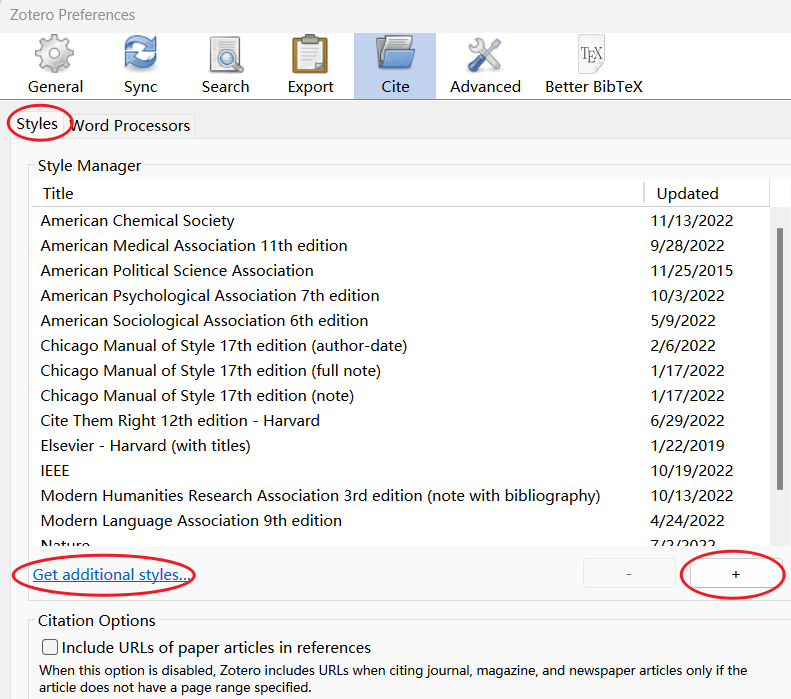

图 5: Zotero 引用样式的添加

你可以从网上搜索你需要的 stl 文件

### 5.2 文字处理软件引用文献

科技工作者一般使用 (1) $\LaTeX$; (2) Markdown; (3) MS Word (or WPS, LibreOffice Writer et al.) 进行科技论文写作，本文介绍如何在这些工具中使用 Zotero

#### 5.2.1 MS Word

1. 在 MS Word (or LO Writer) 上安装 Zotero 插件

在 Zotero 点击“编辑” –> “首选项” –> “引用” –> “文字处理软件” –> ”安装 MS Word (or LibreOffice) 插件“. 安装后 MS Word (or LO Writer) 上会出现 Zotero 菜单项，见 图 6

[figure not shown]

图 6: MS Word 中 Zotero 菜单项

2. 插入文献的引用

在 MS Word 中点击 Zotero –> Add/Edit Citation，选择引用样式，这时会弹出如 图 7 所示的 Zotero 图标，选择 Classic View, 在 Zotero 中选择需要插入的文献

[figure not shown]

图 7: 插入 Zotero 中的文献

值得注意的是，如果我们选择 author-date 的引用样式，Zotero 只能采用聚焦于观点的引用。我们只能采用变通的方法实现聚焦于作者的引用，如先输入作者，然后 再 Add/Edit Citation, 插入时注意勾选 omit author

3. 生成参考文献列表

在 MS Word 需要插入文献列表的地方点击 Zoterro –> Add/Edit Bibliography 即可

如果需要改变文献引用样式，点击 Zotero –> Document Preferences, 在列表中选择所需要的样式

#### 5.2.2 $\LaTeX$ 或 Markdown

$\text{markdown file} \quad \overset{\text{Pandoc}}{\longrightarrow} \quad \text{.tex file} \quad \overset{\LaTeX}{\longrightarrow} \quad \text{.pdf file}$

建议使用 [quarto](https://quarto.org) 来编辑和转换 Markdown 文件

$\LaTeX$ 或 Markdown 使用 Zotero, 一般在 Zotero 中将文献项目转化为 BibTex 文件 (.bib), 然后插入到 Markdown 或 $\LaTeX$ 文件中。

$\LaTeX$ 或 Markdown 中文献的引用，我们将另文阐述

## 6 Harvard style vs Vancouver style

- Harvard referencing uses an author–date system. Sources are cited by the author’s last name and the publication year in brackets. Each Harvard in-text citation corresponds to an entry in the alphabetised reference list at the end of the paper.
- Vancouver referencing uses a numerical system. Sources are cited by a number in parentheses or superscript. Each number corresponds to a full reference at the end of the paper.
- In economics, we use Harvard style more frequently

## 7 叙述引用 vs 插句引用

- 叙述引用: narrative citation, aka writer focused citation
- 插句引用: parenthetical citation, idea focused citation

e.g.

in-text: `Hoffmann (2016) states, blah blah`, `blah blah (Hoffmann, 2016)`

bibliography list:

```
Hoffmann, M. (2016) ‘How is information valued? Evidence from framed field experiments’, The Economic Journal, 126(595), pp. 1884–1911. doi:10.1111/ecoj.12401.
```

## 8 添加文献条目

- 从网页识别
- 手动输入
- 文件导入：RIS, BibTeX, MARC, …
- 通过标示符 (identiﬁer) 添加：DOI, ISBN, PMID, arXiv, …
- 通过 pdf 元数据识别

**ISBN**: international standard book number, 如教材 “Mastering Python for Finance” 的 ISBN 为：978-1-78439-451-6

- 978: prefix, 978 or 979
- 1: registration group, 国家、语言或区位代码, 如美国、英国、澳大利亚等为 0 或 1，中国为 7
- 78439：Publisher identifier，出版社代码
- 451：title identifier, 书序码
- 6：check digit, 校验码， 0 – 9

中文书籍有时候无法识别，可以到 [国家数字图书馆](http://opac.nlc.cn/F) 查询

**DOI**：Digital Object Identifier

https://arxiv.org 一个占坑的网站: 为了防止自己的 idea 在论文被收录前被别人剽窃，将预稿上传到 arxiv 作为预收录

### 8.1 案例1：从百度学术添加文献条目

步骤1：打开[百度学术](https://xueshu.baidu.com)，在搜索栏输入搜索关键词等（比如：公司预盈预亏），得到相关文献列表

步骤2：如 图 8 所示，这时，浏览器的 zotero connector 图标自动变为文件夹形状，表示有多个待选文献条目，点击该图标

[figure not shown]

图 8: 通过百度学术导入文献条目

步骤3：在弹出的文献列表中勾选需要的文献条目

### 8.2 案例2：通过 ISBN 导入文献条目

Ruey S. Tsay 的 Analysis of Financial Time Series (3rd Ed.) 的 ISBN 号为 978-0-470-41435-4

在 Zotero 中，点击第2个图标 (Add Items By Identifier), 输入该书的 ISBN 号，即可导入该文献条目

### 8.3 案例3：通过粘贴板导入

比如粘贴板上为以下内容

```
@article{王春珊2006上市公司盈余预告中的信息含量,
  title={上市公司盈余预告中的信息含量},
  author={王春珊 and 刘习勇},
  journal={统计与决策},
  number={8},
  pages={3},
  year={2006},
}
```

点击 file –> import from clipboard 即可导入该文献条目